# Ejercicios de Correlación

# Ejercicio 6

¿Para cuáles de los 4 conjuntos de datos tiene sentido resumir la relación entre ambas variables con el coeficiente de correlación muestral de Pearson? Para los casos en los cuales contestó que era apropiado,

- 1. calcúlelo usando R.
- 2. Testee las siguientes hipótesis H0 : ρ = 0 H1 : ρ != 0

para cada uno de esos conjuntos. Antes de hacerlo defina a ρ en palabras. Observe que en el ítem 6 (a) calculó un estimador de esta cantidad, para cada conjunto. ¿En qué casos rechaza la hipótesis nula, a nivel 0.05?

**Respuesta:**

Tiene sentido resumir la relación de las variables mediante el coeficiente de correlación muestral de Pearson para los conjuntos de bdims y de cars.

ρ es un coeficiente que indica cuán asociadas se encuentran dos variables. Si toma un valor positivo, significa que cuando una variable aumenta, la otra también lo hace. Si en cambio, toma un valor negativo, cuando una variable aumenta, la otra disminuye. Este coeficiente es un estimador de la correlación poblacional de las variables y se calcula a partir de la muestra observada.

- Bdims:
1. Coeficiente de correlación muestral de Pearson:

```r
cor.test(bdims$wgt, bdims$hgt, method = "pearson")
```

```
    Pearson's product-moment correlation

data:  bdims$wgt and bdims$hgt
t = 23.135, df = 505, p-value < 2.2e-16
alternative hypothesis: true correlation is not equal to 0
95 percent confidence interval:
 0.6722075 0.7570923
sample estimates:
      cor
0.7173011
```

2. H0 se rechaza.
- Cars:
1. Coeficiente de correlación muestral de Pearson:

```r
cor.test(cars$weight, cars$mpgCity, method = "pearson")
```

```
    Pearson's product-moment correlation

data:  cars$weight and cars$mpgCity
t = -13.157, df = 52, p-value < 2.2e-16
alternative hypothesis: true correlation is not equal to 0
95 percent confidence interval:
 -0.9270125 -0.7960809
sample estimates:
       cor
-0.8769183
```

2. H0 se rechaza.

# Ejercicio 7

**Mamíferos, Parte II.** El conjunto de datos de mammals presenta un scatterplot que no es razonable resumir con el coeficiente de correlación muestral. El gráfico no es lindo por varios motivos, básicamente las observaciones parecen estar en escalas distintas, hay muchas observaciones superpuestas, necesitaríamos hacer un zoom del gráfico en la zona cercana al origen, a expensas de perder las dos observaciones con valores mucho más grandes que el resto. Podemos comparar lo que pasaría si no hubiéramos observado el diagrama de dispersión y quisiéramos resumir los datos con el coeficiente de correlación.

- 1. Calcule el coeficiente de correlación muestral de Pearson para los 62 mamíferos.
- 2. Identifique las dos observaciones que tienen valores de peso corporal y cerebral más grandes que el resto. Realice un scatter plot de las restantes 60 variables. ¿Cómo podría describir este gráfico? Calcule el coeficiente de correlación muestral de Pearson para estas 60 observaciones.
- 3. El gráfico hecho en el ítem anterior no corrige el problema original del todo. La forma general podría describirse como un abanico: claramente las variables están asociadas, la asociación es positiva (ambas crecen simultáneamente) pero la dispersión de los datos parece aumentar a medida que ambas variables aumentan. Esta forma es frecuente en los conjuntos de datos, suelen corresponder a observaciones que están medidas en escalas que no son comparables entre sí y suele corregirse al tomar logaritmo en ambas variables. Para ver el efecto de transformar las variables, realice un scatterplot con todas las observaciones, del logaritmo (en base 10, o en base e) del peso del cerebro en función del logaritmo del peso corporal. Observe el gráfico. ¿Cómo lo describiría? Calcule la correlación de Pearson para los datos transformados.
- 4. Para ambos conjuntos de datos (transformados por el logaritmo y sin transformar) calcule la correlación de Spearman.

**Respuesta:**

1. Coeficiente de correlación de Pearson con las 62 observaciones:

```r
cor(mammals$BodyWt, mammals$BrainWt)
```

```
[1] 0.9341638
```

2. Detección de máximos:

```r
mammals %>%
  select(Species, BodyWt, BrainWt) %>%
  arrange(desc(BodyWt), desc(BrainWt))
```

| Species | BodyWt | BrainWt |
| --- | --- | --- |
| Africanelephant | 6654.000 | 5712.00 |
| Asianelephant | 2547.000 | 4603.00 |
| Giraffe | 529.000 | 680.00 |
| Horse | 521.000 | 655.00 |
| Cow | 465.000 | 423.00 |
| Okapi | 250.000 | 490.00 |
| Gorilla | 207.000 | 406.00 |
| Pig | 192.000 | 180.00 |
| Donkey | 187.100 | 419.00 |
| Braziliantapir | 160.000 | 169.00 |

[output cut: 52 more lines]

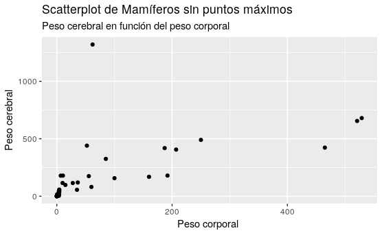

```r
mammals2 <- mammals[!mammals$Species%in%c('Africanelephant','Asianelephant'),]

ggplot(data=mammals2, aes(x=BodyWt, y=BrainWt)) +
  geom_point() +
  labs(title = "Scatterplot de Mamíferos sin puntos máximos", subtitle = "Peso cerebral en función del peso corporal", x = "Peso corporal ", y = "Peso cerebral")
```

Se observa:

- Forma: no lineal
- Dirección: positiva
- Fuerza: moderada

```r
cor(mammals2$BodyWt, mammals2$BrainWt, method="pearson")
```

```
[1] 0.6505592
```

3. Nueva base con logaritmos:

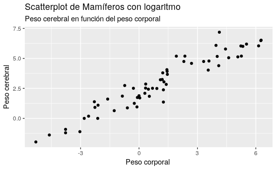

```r
mammalslog <- mammals2 %>%
  select(BodyWt, BrainWt) %>%
  mutate(BodyWt=log(BodyWt),
         BrainWt=log(BrainWt))
ggplot(data=mammalslog, aes(x=BodyWt, y=BrainWt)) +
  geom_point() +
  labs(title = "Scatterplot de Mamíferos con logaritmo", subtitle = "Peso cerebral en función del peso corporal", x = "Peso corporal ", y = "Peso cerebral")
```

Se observa:

- Forma: lineal
- Dirección: positiva
- Fuerza: fuerte

```r
cor(mammalslog$BodyWt, mammalslog$BrainWt, method="pearson")
```

```
[1] 0.9516837
```

4. Correlación de Spearman para datos sin tranformar:

```r
cor(mammals2$BodyWt, mammals2$BrainWt, method="spearman")
```

```
[1] 0.9486905
```

Correlación de Spearman para datos tranformados:

```r
cor(mammalslog$BodyWt, mammalslog$BrainWt, method="spearman")
```

```
[1] 0.9486905
```

# Ejercicio 8

¿Con qué coeficiente de correlación, Pearson o Spearman, resumiría los datos de cars? (weight, mpgCity)?

**Respuesta:**

Con Pearson. Spearman se utiliza cuando hay valores atípicos o se desea prescindir de la normalidad.